# Shiny

## Agenda

- Shiny Apps
- Readings:
  - [RStudio Shiny Tutorial](https://shiny.rstudio.com/tutorial/)
  - [Zev Ross’ Shiny Tutorials](http://zevross.com/blog/2016/04/19/r-powered-web-applications-with-shiny-a-tutorial-and-cheat-sheet-with-40-example-apps/)

## Getting started

```r
#install.packages("shiny")
library(shiny)
```

The `shiny` package has 11 built-in examples that demonstrate different features of `shiny`, and we’ll take a look at a couple of them.

## Histogram Shiny

```r
runExample("01_hello")
```

## Structure

Shiny apps are contained in a single script called `app.R`. The script `app.R` lives in a directory (for example, `newdir/`) and the app can be run with `runApp("newdir")`.

`app.R` has three potential components:

- a user interface (ui) object (controls the layout and appearance)
- a server function (contains the instructions that your computer needs to build your app)
- a call to the shinyApp function (creates Shiny app objects from an explicit UI/server pair)

## Building an app

Minimum template:

```r
library(shiny)

# Define UI ----
ui <- fluidPage(

)

# Define server logic ----
server <- function(input, output) {

}

# Run the app ----
shinyApp(ui = ui, server = server)
```

## Layout

`fluidPage` creates a display that automatically adjusts to the size of the window.

- Place elements in the `fluidPage` function to layout your app
  - `titlePanel`
  - `sidebarLayout`, with `sidebarPanel` and `mainPanel`

## Layout

```r
ui <- fluidPage(
  titlePanel("title panel"),

  sidebarLayout(position = "right",
                sidebarPanel("sidebar panel"),
                mainPanel("main panel")
  )
)
```

```r
runApp("08-shiny-apps/shiny1")
```

## Layout

Other options:

- There are a lot [here](https://shiny.rstudio.com/articles/layout-guide.html)
- `fluidRow` and `column` build your layout up from a grid system
- `navbarPage` to give your app a multi-page user interface that includes a navigation bar

## HTML content

There are a bunch of HTML5 equivalencies you can use as well (tag functions)

- `p` for paragraphs
- h1`:`h6` for different header levels
- `a` for hyperlinks
- `img` for images
  - must be in a subdirectory called `www`

In general, any HTML tag attribute can be set as an argument in any Shiny tag function

## Building on

```r
    sidebarLayout(
        sidebarPanel(
            h2("Installation"),
            p("Shiny is available on CRAN, so you can install it in the usual way from your R console:"),
            code('install.packages("shiny")'),
            br(),
            br(),
            br(),
            br(),
            img(src = "rstudio.png", height = 70, width = 200),
            br(),
            "Shiny is a product of ",
            span("RStudio", style = "color:blue")
        ),
```

## Building on

```r
        mainPanel(
            h1("Introducing Shiny"),
            p("Shiny is a new package from RStudio that makes it ",
              em("incredibly easy "),
              "to build interactive web applications with R."),
            br(),
            p("For an introduction and live examples, visit the ",
              a("Shiny homepage.",
                href = "http://shiny.rstudio.com")),
            br(),
            h2("Features"),
            p("- Build useful web applications with only a few lines of code—no JavaScript required."),
            p("- Shiny applications are automatically 'live' in the same way that ",
              strong("spreadsheets"),
              " are live. Outputs change instantly as users modify inputs, without requiring a reload of the browser.")
        )
```

## Building on

```r
runApp("08-shiny-apps/shiny2")
```

## Control widgets

- Web element that your users can interact with.
- Widgets provide a way for your users to send messages to the Shiny app.

## Control widgets

- `actionButton`: Action Button
- `checkboxGroupInput`: A group of check boxes
- `checkboxInput`: A single check box
- `dateInput`: A calendar to aid date selection
- `dateRangeInput`: A pair of calendars for selecting a date range
- `fileInput`: A file upload control wizard
- `helpText`: Help text that can be added to an input form

## Control widgets

- `numericInput`: A field to enter numbers
- `radioButtons`: A set of radio buttons
- `selectInput`: A box with choices to select from
- `sliderInput`: A slider bar
- `submitButton`: A submit button
- `textInput`: A field to enter text

## Control widgets

Add the function to `sidebarPanel` or `mainPanel`

Each widget function requires several arguments. The first two arguments for each widget are:

- a *name* for the widget: unseen by user; character string
- a *label*: appears with widget; character string

## Control widgets

```r
fluidRow(

    column(3,
           h3("Buttons"),
           actionButton("action", "Action"),
           br(),
           br(),
           submitButton("Submit")),

    column(3,
           h3("Single checkbox"),
           checkboxInput("checkbox", "Choice A", value = TRUE)),
```

## Control widgets

```r
column(3,
           checkboxGroupInput("checkGroup",
                              h3("Checkbox group"),
                              choices = list("Choice 1" = 1,
                                             "Choice 2" = 2,
                                             "Choice 3" = 3),
                              selected = 1)),

    column(3,
           dateInput("date",
                     h3("Date input"),
                     value = "2014-01-01"))
  ),
```

## Control widgets

```r
fluidRow(

    column(3,
           dateRangeInput("dates", h3("Date range"))),

    column(3,
           fileInput("file", h3("File input"))),

    column(3,
           h3("Help text"),
           helpText("Note: help text isn't a true widget,",
                    "but it provides an easy way to add text to",
                    "accompany other widgets.")),

    column(3,
           numericInput("num",
                        h3("Numeric input"),
                        value = 1))
  ),
```

## Control widgets

```r
fluidRow(

    column(3,
           radioButtons("radio", h3("Radio buttons"),
                        choices = list("Choice 1" = 1, "Choice 2" = 2,
                                       "Choice 3" = 3),selected = 1)),

    column(3,
           selectInput("select", h3("Select box"),
                       choices = list("Choice 1" = 1, "Choice 2" = 2,
                                      "Choice 3" = 3), selected = 1)),
```

## Control widgets

```r
column(3,
           sliderInput("slider1", h3("Sliders"),
                       min = 0, max = 100, value = 50),
           sliderInput("slider2", "",
                       min = 0, max = 100, value = c(25, 75))
    ),

    column(3,
           textInput("text", h3("Text input"),
                     value = "Enter text..."))
  )
```

## Control widgets

```r
runApp("08-shiny-apps/shiny3")
```

## More information

Check out the [widget gallery](https://shiny.rstudio.com/gallery/widget-gallery.html) for more ideas

- code provided
- information about the values and how they change

## Reactive output

- Automatically changes when the user toggles a widget
- You can create reactive output with a two step process.
  1. Add an R object to your user interface.
  2. Tell Shiny how to build the object in the server function.

## R objects

- `dataTableOutput`: DataTable
- `htmlOutput`: raw HTML
- `imageOutput`: image
- `plotOutput`: plot
- `tableOutput`: table
- `textOutput`: text
- `uiOutput`: raw HTML
- `verbatimTextOutput`: text

## Output in ui

```r
    mainPanel(
      textOutput("selected_var"),
      textOutput("min_max")
    )
```

- `textOutput`: add a reactive line of text
- `selected_var` and `min_max`: single strings, names of your reactive elements

## Build the object

The `server` function creates a list-like object `output`

- each object needs its own entry

```r
server <- function(input, output) {

  output$selected_var <- renderText({
    paste("You have selected", input$var)
  })

  output$min_max <- renderText({
    paste("You have chosen a range that goes from",
          input$range[1], "to", input$range[2])
  })

}
```

## Render functions

Each entry to `output` should contain a `render*` output:

- `renderDataTable`: DataTable
- `renderImage`: images (saved as a link to a source file)
- `renderPlot`: plots
- `renderPrint`: any printed output
- `renderTable`: data frame, matrix, other table like structures
- `renderText`: character strings
- `renderUI`: a Shiny tag object or HTML

Each render* function takes a single argument: an R expression surrounded by braces, {}

## Reactive elements

```r
runApp("08-shiny-apps/shiny4")
```

## Census data

```r
counties <- readRDS("08-shiny-apps/census-app/data/counties.rds")
head(counties)
##              name total.pop white black hispanic asian
## 1 alabama,autauga     54571  77.2  19.3      2.4   0.9
## 2 alabama,baldwin    182265  83.5  10.9      4.4   0.7
## 3 alabama,barbour     27457  46.8  47.8      5.1   0.4
## 4    alabama,bibb     22915  75.0  22.9      1.8   0.1
## 5  alabama,blount     57322  88.9   2.5      8.1   0.2
## 6 alabama,bullock     10914  21.9  71.0      7.1   0.2
```

## helpers.R

The `helpers.R` script plots the following data (only really designed for this file) – it just calls `map` and adds legends, essentially

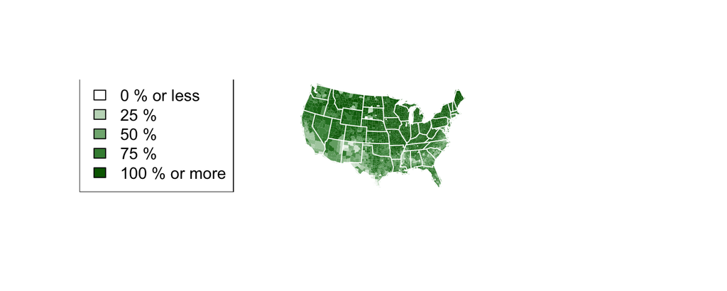

```r
library(maps)
library(mapproj)
source("08-shiny-apps/census-app/helpers.R")
counties <- readRDS("08-shiny-apps/census-app/data/counties.rds")
percent_map(var=counties$white, color="darkgreen", legend.title="% White", min=0, max=100)
```

## Same thing, shiny

Shiny runs commands from `server.R` (or `app.R` for single files), and treats its location as the working directory

## Census viewer

```r
runApp("08-shiny-apps/census-app")
```

## New example - stock visualizations

```r
runApp("08-shiny-apps/stockVis")
```

## stockVis

`stockVis` relies heavily on two functions from the `quantmod` package:

- `getSymbols` to download financial data
- `chartSeries` to display prices in an attractive chart.

`helpers.R` contains a function that adjusts stock prices for inflation.

## Reactive expressions

- A reactive expression saves its result the first time you run it.
- The next time the reactive expression is called, it checks if the saved value has become out of date (i.e., whether the widgets it depends on have changed).
  - If the value is out of date, the reactive object will recalculate it (and then save the new result).
  - If the value is up-to-date, the reactive expression will return the saved value without doing any computation.

## Stock visualization app

```r
runApp("08-shiny-apps/stockVis")
```

## Reactive expressions

- Takes input values, or values from other reactive expressions, and returns a new value
- Save their results, and will only re-calculate if their input has changed
- Create with `reactive({ })`
- Call with the name of the expression followed by parentheses `()`
- Only call from within other reactive expressions or `render*` functions

## Sharing apps

- As `R` scripts (requires your user to know how to use R to some degree)
- As a web page

## Sharing as R scripts

- Zip the app folder, and user runs with `library(shiny); runApp("my_app")`
- Host it on a website, user runs with `library(shiny); runUrl( "<the weblink>")`
- Host it on GitHub, user runs with `library(shiny); runGitHub( "<your repository name>", "<your user name>")`
- Host it on Gist, user runs with `library(shiny); runGist("<gist number>")`

## Sharing as web pages

- shinyapps.io (a limited free option, several other tiers)
- Shiny Server (free, requires a Linux server)
- RStudio Connect (for profit, expensive)